# Optimization of Bus Routes in Pangyo Techno Valleys_2

### 3-3. 판교 제2ㆍ3테크노밸리 통행량 상위 그리드 도출 및 클러스터링

앞서 수행한 히트맵 시각화를 통해 판교 제2·3테크노밸리의 출퇴근 첨두시간에 발생하는 승용차 통행량의 출발지와 도착지의 공간적 분포를 확인하였다. 그 결과 출퇴근 첨두시간의 승용차 통행은 특정 지역에서 집중적으로 발생함을 거시적으로 파악하였다. 이를 바탕으로 본 절에서는 500m 격자 수준으로 통행량이 집중된 상위 지역을 도출하고, 이를 K-means 클러스터링을 통해 승용차 통근 통행량이 집중된 주요 군집을 식별하고자 한다.

우선 출퇴근 첨두시간에 해당하는 시간코드의 일평균 전수화 통행량을 기준으로, 2023년 1~4분기 전체 O/D 데이터의 출발지별 평균 통행량을 산출하였다. 출발지별 평균값을 구하기 위해 분기별 데이터를 통합하고, 각 출발 격자 ID별로 시간대별 통행량을 평균내어 출근·퇴근 시간대의 가중 통행량 합산값을 생성하였다. 이후, 국토정보플랫폼에서 제공하는 전국 500m 빈격자 데이터(shp)와 전처리된 통행량 데이터를 출발 격자 ID 기준으로 공간 조인하여, 각 격자별 총 통행량을 부여한 공간 데이터셋을 구축하였다.

격자별 통행량의 분포 특성을 반영하기 위해 Jenks Natural Breaks(네추럴 브레이크) 기법을 적용하여 5개 등급으로 구간화하였다. 이 기법은 각 그룹의 내부 편차를 최소화하고 그룹 간 분산을 최대화하는 방식으로, 공간 데이터의 군집 특성을 효과적으로 분류할 수 있다는 점에서 적합하다. 아래는 판교 제2·3테크노밸리 승용차 통근 통행 발생지역을 그리드 단위로 단계구분도 시각화를 진행하는 과정이다.

```python
grid_traffic = df_출근.dropna(subset=['8_평균']) # 8_평균 값이 Nan인 행은 제거
grid_traffic = grid_traffic[['SPO_NO_CD', 'geometry', '8_평균']] # 단계구분도에 필요한 열만 추출
```

```python
colors = ['#f7fbff', '#9ac8e0', '#529dcc', '#1d6cb1', '#08306b'] # 단계구분도 만들 색상 지정
```

```python
# Natural Breaks 구간 분류 (k=5), 초기값 고정
classifier = mapclassify.NaturalBreaks(
    grid_traffic['8_평균'],
    k=5,
    initial=100  # 초기값 고정 (int 값 추천)
)
bins = classifier.bins  # 구간 경계값
grid_traffic['breaks'] = classifier.yb  # 각 행의 구간 번호 저장

from branca.colormap import StepColormap

colormap = StepColormap(
    colors=colors,
    index=[grid_traffic['8_평균'].min()] + list(bins),
    vmin=grid_traffic['8_평균'].min(),
    vmax=grid_traffic['8_평균'].max(),
    caption='8_평균 (Natural Breaks)'
)
```

```python
# 지도 생성
choropleth_map = folium.Map(location=[37.53342, 127.1746], zoom_start=9)

# 브이월드 배경지도
layer = "Base"
tileType = "png"
tiles = f"http://api.vworld.kr/req/wmts/1.0.0/{vworld_key}/{layer}/{{z}}/{{y}}/{{x}}.{tileType}"
attr = "Vworld"

folium.TileLayer(
    tiles=tiles,
    attr=attr,
    overlay=True,
    control=True
).add_to(choropleth_map)

folium.GeoJson(
    grid_traffic,
    style_function=lambda feature: {
        'fillColor': colormap(feature['properties']['8_평균']),
        'color': 'black',
        'weight': 0.3,
        'fillOpacity': 0.8
    },
    tooltip=folium.GeoJsonTooltip(
        fields=['8_평균'],
        aliases=['8_평균:'],
        localize=True
    ),
    name='통행량 단계구분도'
).add_to(choropleth_map)

colormap.add_to(choropleth_map)
folium.LayerControl().add_to(choropleth_map)

choropleth_map
```

Make this Notebook Trusted to load map: File -> Trust Notebook

[interactive chart not shown]

```python
grid_traffic['breaks'].value_counts()
```

```
breaks
0    5926
1     939
2     289
3      78
4       8
Name: count, dtype: int64
```

```python
# 상위 그리드만 필터링
high_traffic = grid_traffic[grid_traffic['breaks'].isin([3,4])]
# 클러스터링을 위해 그리드 중심점 추출
high_traffic['centroid'] = high_traffic.geometry.centroid
high_traffic['lon'] = high_traffic['centroid'].x # 중심점 경도 추출
high_traffic['lat'] = high_traffic['centroid'].y # 중심점 위도 추출
```

```python
from sklearn.cluster import KMeans
data = high_traffic[['lon', 'lat']] # 클러스터링 변수로 사용할 위경도 데이터
```

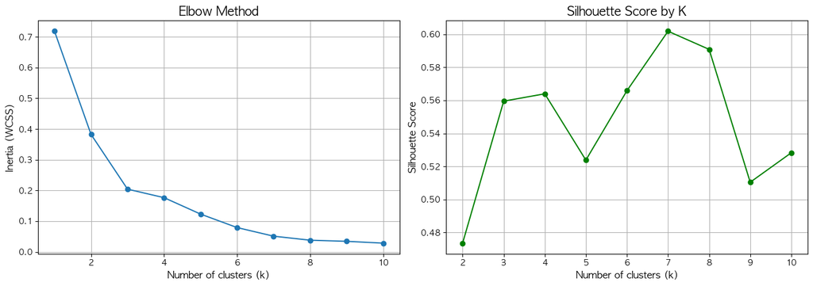

```python
from sklearn.metrics import silhouette_score

inertias = []
silhouette_scores = []
K_range_elbow = range(1, 11)
K_range_silhouette = range(2, 11) # 실루엣 계수는 최소 2개부터 계산 가능

# Elbow 계산
for k in K_range_elbow:
    model = KMeans(n_clusters=k, random_state=10)
    model.fit(data)
    inertias.append(model.inertia_)

# Silhouette 계산
for k in K_range_silhouette:
    model = KMeans(n_clusters=k, random_state=10)
    labels = model.fit_predict(data)
    score = silhouette_score(data, labels)
    silhouette_scores.append(score)

# 1X2 서브플롯 생성
fig, axes = plt.subplots(nrows=1, ncols=2, figsize=(14, 5))

# 왼쪽: Elbow
axes[0].plot(K_range_elbow, inertias, marker='o')
axes[0].set_title('Elbow Method', fontsize=15)
axes[0].set_xlabel('Number of clusters (k)', fontsize=12)
axes[0].set_ylabel('Inertia (WCSS)', fontsize=12)
axes[0].grid(True)

# 오른쪽: Silhouette
axes[1].plot(K_range_silhouette, silhouette_scores, marker='o', color='green')
axes[1].set_title('Silhouette Score by K', fontsize=15)
axes[1].set_xlabel('Number of clusters (k)', fontsize=12)
axes[1].set_ylabel('Silhouette Score', fontsize=12)
axes[1].grid(True)

plt.tight_layout()
plt.show()
```

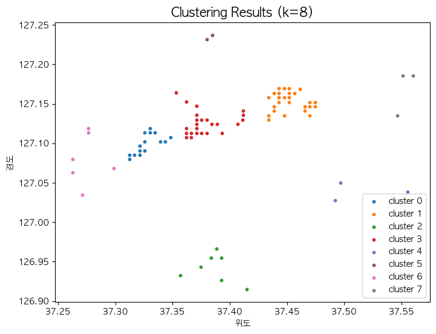

```python
# 모델 학습
k = 8
model = KMeans(n_clusters=k, random_state=10)
high_traffic['cluster'] = model.fit_predict(data) # 클러스터링 결과 저장

# 클러스터링 결과 시각화
plt.rcParams['font.family'] = 'AppleGothic'
plt.figure(figsize=(8, 6))
for i in range(k):
    plt.scatter(high_traffic.loc[high_traffic['cluster'] == i, 'lat'],
                high_traffic.loc[high_traffic['cluster'] == i, 'lon'],
                label=f'cluster {i}', s=10)

plt.legend()
plt.title('Clustering Results (k=8)', fontsize=15)
plt.xlabel('위도')
plt.ylabel('경도')
plt.show()
```

```python
from folium import CircleMarker
import matplotlib.cm as cm
import matplotlib.colors as colors
```

```python
emd_4326_copy = emd_4326.copy(deep=True)
emd_4326_copy['centroid'] = emd_4326_copy.geometry.centroid

high_traffic_clustering = folium.Map(location=[37.3576, 127.12305], zoom_start=10.4) # 정자동 중심점 확인해서 정자동을 지도 중심으로 사용

# 브이월드 배경지도
layer = "Base"
tileType = "png"
tiles = f"http://api.vworld.kr/req/wmts/1.0.0/{vworld_key}/{layer}/{{z}}/{{y}}/{{x}}.{tileType}"
attr = "Vworld"

folium.TileLayer(
    tiles=tiles,
    attr=attr,
    overlay=True,
    control=True
).add_to(high_traffic_clustering)

folium.GeoJson(
    emd_4326,
    name='읍면동 경계',
    style_function=lambda feature: {
        'fillColor': 'none',   # 채우지 않음
        'color': 'gray',      # 경계선 색
        'weight': 0.5           # 경계선 두께
    }
).add_to(high_traffic_clustering)

for idx, row in emd_4326_copy.iterrows():
    lat = row['centroid'].y
    lon = row['centroid'].x
    name = row['ADM_NM']  # 읍면동 이름

    folium.Marker(
        location=[lat, lon],
        icon=folium.DivIcon(html=f'''
            <div style="
                font-size: 3pt;
                text-align: center;
                white-space: nowrap;
                padding: 1px 3px;
                border-radius: 3px;">
                {name}
            </div>
        ''')
    ).add_to(high_traffic_clustering)

# 클러스터 번호 -> 색상 매핑

cluster_color = {
    0: "#0015ff", # 수지 죽전 일대
    1: '#ff7f0e', # 수진역 모란역 위례 일대
    2: '#2ca02c',
    3: '#9467bd', # 정자 일대
    4: "#000000",
    5: "#fc00a8",
    6: "#ff0000", # 수원 영통 일대
    7: "#44ff00",
}

for _, row in high_traffic.iterrows():
    folium.CircleMarker(
        location=(row['lat'], row['lon']),
        radius=1,
        color=cluster_color[row['cluster']],
        fill=True,
        fill_color=cluster_color[row['cluster']],
        fill_opacity=0.8,
        popup=f"Cluster {row['cluster']}"
    ).add_to(high_traffic_clustering)

high_traffic_clustering
```

<표 2> 승용차 통행량 상위 그리드 클러스터

| 클러스터 번호 | 주요 지역 |
| --- | --- |
| 클러스터 0 | 용인시 수지구 성복동, 풍덕천동, 죽전동 일대 |
| 클러스터 1 | 성남시 수정구 동부, 중원구, 위례 일대 |
| 클러스터 2 | 안양시 산본1동, 호계1동 일대 |
| 클러스터 3 | 성남시 정자동, 수내동, 야탑동 일대 |
| 클러스터 4 | 서울 서초동, 역삼동 일대 |
| 클러스터 5 | 경기 광주시 광남2동 일대 |
| 클러스터 6 | 수원시 영통1동 일대 |
| 클러스터 7 | 서울 강동구 미사, 강일 일대 |

최종적으로 도출된 8개의 클러스터는 <표2>와 같다. 해당 클러스터링 결과는 판교 제2·3테크노밸리로 승용차 통근이 발생하는 주요 지역들을 군집화한 것으로, 도출된 클러스터 별로 해당 지역에서 판교 테크노밸리로 통근하는 이들이 왜 대중교통 대신 승용차를 이용하는지에 대한 원인 분석을 다음 절에서 진행하였다.

### 3-4. 주요 클러스터별 대중교통 환경 및 승용차 통근 발생 원인 정성적 분석

도출된 클러스터별로, 해당 지역에서 판교테크노밸리로 통근하는 이들이 왜 대중교통 대신 승용차를 이용하는지에 대한 원인을 분석하기 위해 네이버맵 길찾기를 통한 정성적 분석과 버스 노선의 효율성을 평가할 수 있는 지표를 통해 정량적 분석 두가지를 진행하였다.

정성적 분석은 네이버맵 길찾기를 바탕으로 경로상의 환승 횟수, 전체 소요 시간의 상대적 차이(승용차 vs 대중교통), 대중교통 배차 간격 및 운행 빈도, 정류장 접근성(퍼스트마일/라스트마일 문제) 등을 조사하였다. 분석 결과 주요 클러스터 지역의 판교 테크노밸리로의 승용차 통근을 유발하는 요인과 결론은 아래와 같다.

[output not shown]

위와같은 정성적 분석 결과를 바탕으로, 주요 클러스터에서 판교 제2·3테크노밸리까지의 대중교통 전환을 저해하는 주요 원인은 “라스트마일 연계 버스노선 문제”로 집약되었다. 이에 따라 개선이 시급한 라스트마일 주요 거점을 다음과 같이 선정하였다.

| 거점 | 문제 요약 |
| --- | --- |
| 이매역 | 수원·용인에서 수인분당선 이용 시 제2밸리와 가장 가까운 역임에도 불구하고 버스 연계 부족으로 라스트마일 단절 발생 |
| 모란역 | 연결 버스 노선의 굴곡 및 배차 간격 문제로 인해 전체 경로 효율성이 낮음 |
| 정자역 | 판교2·3밸리 방면 노선은 존재하나 대부분 장거리 우회 노선으로 인해 너무 긴 소요시간 |
| 판교역 | 물리적 거리상 인접하지만, 제2·3밸리와의 버스 연계가 부족하여 연계 효율이 낮음 |

➡️ 이 4개 거점을 중심으로 라스트마일 개선이 이루어진다면, 승용차 통근자의 대중교통 전환율을 실질적으로 높이고, 단기 교통난 완화 효과를 거둘 수 있을 것으로 기대된다.

## Ⅳ. 경기도 버스 API, 스마트 교통카드 데이터 분석: 상위 클러스터별 대중교통 환경 분석 및 승용차 통근 발생 원인 진단

<그림 8>은 본 분석에 활용한 데이터셋과 분석 툴, 분석 기법, 결과물을 요약한 흐름도이다. 이어지는 단락에서 각 분석 단계에 대해 자세히 설명하겠다.

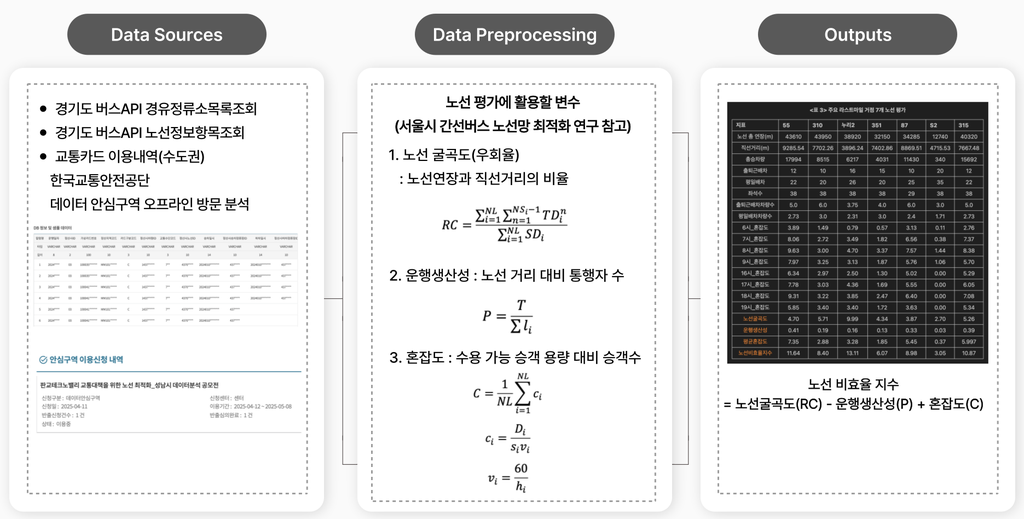

**<그림 8>** 버스 노선 평가 분석 흐름도

### 1. First Mile/Last Mile 개념 및 대중교통에서의 중요성

퍼스트마일(First Mile)과 라스트마일(Last Mile)은 대중교통이나 도시 교통계획에서 매우 핵심적인 개념으로 퍼스트마일은 출발지에서 정류장이나 역까지 이동하는 초기 구간이며, 라스트마일은 대중교통 하차 이후 최종 목적지까지 이동하는 마지막 구간을 말한다. 이 두 구간이 도보로 너무 멀거나, 환승 수단이 부족한 등 연계가 원활하지 않으면, 이용자는 처음부터 대중교통을 포기하고 승용차를 선택할 가능성이 높아진다. 따라서 퍼스트마일과 라스트마일의 연결성을 개선하는 것은 대중교통의 실질적인 접근성과 전환율을 높이는 핵심 전략이며, 특히 교통 혼잡이 심한 도시에서 그 중요성이 더욱 강조된다.  
본 연구는 판교 제2·3테크노밸리로의 승용차 통근 통행량이 많은 지역을 파악한 뒤, 해당 지역에서 승용차 통근 발생 원인을 분석한 결과 승용차 통근 통행량이 많은 지역의 퍼스트마일/라스트마일 문제점을 발견하였으며 이에 초점을 맞춰 대안을 제시하고자 하였다.

### 2. 핵심 라스트마일 거점 버스 노선 평가(최적 노선망 설계에 활용되는 평가지표 활용)

본 연구는 앞서 도출한 4개의 주요 라스트마일 거점(이매역, 모란역, 정자역, 판교역)을 중심으로 판교 제2테크노밸리로 향하는 버스 노선의 현황을 정량적 지표를 통해 평가하였다. 버스 노선 평가에는 ‘델파이 조사 기반의 서울시 간선버스 노선망 최적화 연구(2025, 박수진 외)’에서 제시한 노선굴곡도(RC), 운행생산성(P), 혼잡도(C)를 활용하였으며 수식은 아래와 같다.

##### <수식1> 노선 굴곡도

$$ RC = \frac{\sum_{i=1}^{NL} \sum_{n=1}^{NS_i - 1} TD_i^n}{\sum_{i=1}^{NL} SD_i} $$

- **RC**: 전체 노선의 평균 굴곡도
- **TDin**: 노선 *i*의 *n*~*n+1* 정류장 간 거리 (km)
- **SDi**: 노선 *i*의 기점~종점 간 직선거리 (km)
- **NL**: 전체 노선 수
- **NSi**: 노선 *i*의 정류장 수

##### <수식2> 운행 생산성

$$ P = \frac{T}{\sum l_i} $$

- **P**: 버스 노선망의 운행 생산성 (인/km)
- **T**: 전체 통행자 수
- **li**: 노선 *i*의 연장 (km)

##### <수식3> 혼잡도

$$ C = \frac{1}{NL} \sum_{i=1}^{NL} c_i $$

$$ c_i = \frac{D_i}{s_i \cdot v_i} \qquad v_i = \frac{60}{h_i} $$

- **C**: 전체 네트워크 평균 혼잡도
- **ci**: 노선 *i*의 재차율
- **Di**: 노선 *i*의 시간당 수요 (인/시)
- **si**: 노선 *i*의 좌석 수
- **hi**: 노선 *i*의 배차 간격 (분)
- **vi**: 노선 *i*의 시간당 운행 횟수

이 지표들을 산출하기 위해 한국교통안전공단의 교통카드 데이터(2024년 12월 16일~20일, 평일 기준 5일)와 경기버스 API 데이터를 활용하였다. 분석 대상은 4개 거점에서 출발해 판교 제2테크노밸리로 향하는 총 7개 노선(55번, 310번, 누리2, 87번, 351번, S2, 315번)이다. 운행생산성은 높을수록 좋은 지표이기 때문에 음수처리를 하여 최종적으로 노선 비효율 지수는 노선굴곡도(RC) - 운행생산성(P) + 혼잡도(C)로 계산하였다. $$ 노선 비효율 지수 = 노선굴곡도(RC) - 운행생산성(P) + 혼잡도(C) $$

### 2-1. 버스 API 전처리

#### 2-1-1. 경유정류소목록조회 API

데이터 출처 : https://www.data.go.kr/tcs/dss/selectApiDataDetailView.do?publicDataPk=15080662

```python
import requests

serviceKey ='IRKfxApqigmEUv%2FavTOjjm%2B7MbkydNmffTJnLDBrLfZbQ8SUWM%2BbyW9NRDJ8XZVM1yIoJnSoafjvk0v61umzog%3D%3D'
route = {55:204000017, 310:204000163, '누리2':204000146, 87:241213007, 351:204000182, 'S2':204000183, 315:204000073} # 우리가 필요한 노선의 노선명과 노선ID 딕셔너리 생성(노선ID는 api에서 조회)
results = {} # 결과를 담을 빈 딕셔너리 생성

for routeName, routeId  in route.items():
    url_stationlist = f'http://apis.data.go.kr/6410000/busrouteservice/v2/getBusRouteStationListv2?serviceKey={serviceKey}&routeId={routeId}&format=json' # 경유정류소목록조회
    print(url_stationlist)
    response = requests.get(url_stationlist)
    if response.status_code == 200:
        data = response.json()
        results[f"route_{routeName}"] = data
    else:
        print(f"{routeName} 호출 실패: {response.status_code}")

results['route_55']
```

```python
results['route_55']['response']['msgBody']['busRouteStationList'][:2]
```

```
[{'centerYn': 'N',
  'districtCd': 2,
  'mobileNo': ' 05257',
  'regionName': '성남',
  'stationId': 204000284,
  'stationName': '(임시)금토동삼거리',
  'x': 127.0898167,
  'y': 37.4078,
  'adminName': '경기도 성남시',
  'stationSeq': 1,
  'turnSeq': 58,
  'turnYn': 'N'},
 {'centerYn': 'N',
  'districtCd': 2,
  'mobileNo': ' 05341',
  'regionName': '성남',
  'stationId': 204000158,
  'stationName': '텔레칩스',
  'x': 127.0873667,
  'y': 37.40645,
  'adminName': '경기도 성남시',
  'stationSeq': 2,
  'turnSeq': 58,
  'turnYn': 'N'}]
```

```python
df_dic_station = {}

for n in list(route.keys()):
    station_list = results[f'route_{n}']['response']['msgBody']['busRouteStationList']
    df_dic_station[f"df_{n}"] = pd.DataFrame(station_list)

df_dic_station['df_55'].head(3)
```

|  | centerYn | districtCd | mobileNo | regionName | stationId | stationName | x | y | adminName | stationSeq | turnSeq | turnYn |
| --- | --- | --- | --- | --- | --- | --- | --- | --- | --- | --- | --- | --- |
| 0 | N | 2 | 05257 | 성남 | 204000284 | (임시)금토동삼거리 | 127.089817 | 37.407800 | 경기도 성남시 | 1 | 58 | N |
| 1 | N | 2 | 05341 | 성남 | 204000158 | 텔레칩스 | 127.087367 | 37.406450 | 경기도 성남시 | 2 | 58 | N |
| 2 | N | 2 | 05343 | 성남 | 204000160 | 판교이노베이션랩 | 127.085883 | 37.405633 | 경기도 성남시 | 3 | 58 | N |

```python
for l in list(df_dic_station.keys()):
    df_dic_station[l].to_csv(f'./data/{l}.csv') # api에서 전처리한 노선별 경유정류소목록 데이터프레임 내보내기
```

#### 2-1-2. 노선정보조회 API

데이터 출처 : https://www.data.go.kr/tcs/dss/selectApiDataDetailView.do?publicDataPk=15080662

```python
for routeName, routeId  in route.items():
    url_stationlist = f'http://apis.data.go.kr/6410000/busrouteservice/v2/getBusRouteInfoItemv2?serviceKey={serviceKey}&routeId={routeId}&format=json' # 노선정보조회
    print(url_stationlist)
    response = requests.get(url_stationlist)
    if response.status_code == 200:
        data = response.json()
        results[f"route_{routeName}"] = data
    else:
        print(f"{routeName} 호출 실패: {response.status_code}")
```

```python
results['route_55']['response']['msgBody']['busRouteInfoItem']
```

```python
df_dic_businfo = {}

for n in list(route.keys()):
    routeinfo = results[f'route_{n}']['response']['msgBody']['busRouteInfoItem']
    df_dic_businfo[f"businfo_{n}"] = pd.DataFrame([routeinfo])
```

```python
df_dic_businfo['businfo_55']
```

|  | adminName | companyId | companyName | companyTel | districtCd | downFirstTime | downLastTime | endMobileNo | endStationId | endStationName | ... | upFirstTime | upLastTime | weDownFirstTime | weDownLastTime | weNPeekAlloc | wePeekAlloc | weUpFirstTime | weUpLastTime | nPeekAlloc | nightAlloc |
| --- | --- | --- | --- | --- | --- | --- | --- | --- | --- | --- | --- | --- | --- | --- | --- | --- | --- | --- | --- | --- | --- |
| 0 | 경기도 성남시 | 4102600 | 성남시내버스 | 031-747-3200 | 2 | 04:00 | 23:20 | 6213 | 205000045 | 남한산성공원입구.양지파출소 | ... | 04:00 | 22:00 | 04:00 | 23:20 | 28 | 18 | 04:00 | 22:00 | 20 | 0 |

1 rows × 46 columns

```python
final_dic = {}
for k in list(df_dic_businfo.keys()):
    df = df_dic_businfo[f"{k}"].rename(columns = {'adminName':'인면허기관명',
                                                  'companyId':'운수업체아이디',
                                                  'companyName':'운수업체명',
                                                  'companyTel':'운수업체 전화번호',
                                                  'districtCd':'구역코드',
                                                  'downFirstTime':'평일 종점 첫차시간',
                                                  'downLastTime':'평일 종점 막차시간',
                                                  'endMobileNo':'종점모바일번호',
                                                  'endStationId':'종점정류소아이디',
                                                  'endStationName':'종점정류소명',
                                                  'garageName':'차고지명',
                                                  'garageTel':'차고지연락처',
                                                  'multiFlag':'여러노선여부',
                                                  'peekAlloc':'평일 최소 배차시간(분)',
                                                  'regionName':'운행지역',
                                                  'routeId':'노선아이디',
                                                  'routeName':'노선번호',
                                                  'routeTypeCd':'노선유형코드',
                                                  'routeTypeName':'노선유형명',
                                                  'satDownFirstTime':'토요일 종점 첫차시간', 'satDownLastTime':'토요일 종점 막차시간',
                                                  'satNPeekAlloc':'토요일 최대 배차시간(분)',
                                                  'satPeekAlloc':'토요일 최소 배차시간(분)',
                                                  'satUpFirstTime':'토요일 기점 첫차시간',
                                                  'satUpLastTime':'토요일 기점 막차시간', 'startMobileNo':'기점모바일번호',
                                                  'startStationId':'기점정류소아이디',
                                                  'startStationName':'기점정류소명',
                                                  'sunDownFirstTime':'일요일 종점 첫차시간', 'sunDownLastTime':'일요일 종점 막차시간',
                                                  'sunNPeekAlloc':'일요일 최대 배차시간(분)',
                                                  'sunPeekAlloc':'일요일 최소 배차시간(분)',
                                                  'sunUpFirstTime':'일요일 기점 첫차시간',
                                                  'sunUpLastTime':'일요일 기점 막차시간',
                                                  'turnStID':'회차정류장ID',
                                                  'turnStNm':'회차정류장명',
                                                  'upFirstTime':'평일 기점 첫차시간',
                                                  'upLastTime':'평일 기점 막차시간',
                                                  'weDownFirstTime':'공휴일 종점 첫차시간',
                                                  'weDownLastTime':'공휴일 종점 막차시간',
                                                  'weNPeekAlloc':'공휴일 최대 배차시간(분)',
                                                  'wePeekAlloc':'공휴일 최소 배차시간(분)',
                                                  'weUpFirstTime':'공휴일 기점 첫차시간',
                                                  'weUpLastTime':'공휴일 기점 막차시간',
                                                  'nPeekAlloc':'평일 최대 배차시간(분)',
                                                  'nightAlloc':'야간배차시간'})

    df = df.melt(id_vars=['노선번호'], var_name='컬럼명', value_name='값')
    final_dic[f"{k}"] = df


final_dic['businfo_55']
```

[output not shown]

```python
df_combined = pd.concat(final_dic.values(), axis=0, ignore_index=True)
df_combined.head()
```

|  | 노선번호 | 컬럼명 | 값 |
| --- | --- | --- | --- |
| 0 | 55 | 인면허기관명 | 경기도 성남시 |
| 1 | 55 | 운수업체아이디 | 4102600 |
| 2 | 55 | 운수업체명 | 성남시내버스 |
| 3 | 55 | 운수업체 전화번호 | 031-747-3200 |
| 4 | 55 | 구역코드 | 2 |

```python
df_combined.to_csv('./data/businfo.csv', index=False)
```

### 2-1. 노선 굴곡도 변수 산출

노선굴곡도는 노선의 정류장 간 거리의 총합을 노선의 기점~종점 간 직선거리로 나누어 산출된다. 즉 노선의 직선거리 대비 실제 노선의 길이 비율을 계산하여 해당 노선의 우회율을 나타내는 값을 산출하는 것이다. 따라서 노선굴곡도 변수 산출을 위해서 필요한 데이터는 다음과 같다.

- 노선의 정류장 간 거리
- 노선의 기점, 종점 정류장 정보(위경도 포함)

노선의 정류장 간 거리는 데이터안심구역에서 제공하는 한국교통안전공단의 '교통카드 이용내역(수도권)' 데이터를 오프라인 방문 분석하여 반출하였다. (https://dsz.kdata.or.kr/svc/data/search.do)  
노선의 기점, 종점 정류장 정보는 경기도 버스 API를 활용하였다.

```python
distance = pd.read_csv('./data/노선거리_데이터안심구역.csv') # 노선 전체 연장(거리) 데이터프레임 불러오기
distance.head()
```

|  | 55 | 310 | 누리2 | 351 | 87 | S2 | 315 |
| --- | --- | --- | --- | --- | --- | --- | --- |
| 0 | 43610 | 43950 | 38920 | 32150 | 34285 | 12740 | 40320 |

```python
businfo = pd.read_csv('./data/businfo.csv')
businfo[businfo['노선번호'] == '55']
```

|  | 노선번호 | 컬럼명 | 값 |
| --- | --- | --- | --- |
| 0 | 55 | 인면허기관명 | 경기도 성남시 |
| 1 | 55 | 운수업체아이디 | 4102600 |
| 2 | 55 | 운수업체명 | 성남시내버스 |
| 3 | 55 | 운수업체 전화번호 | 031-747-3200 |
| 4 | 55 | 구역코드 | 2 |
| 5 | 55 | 평일 종점 첫차시간 | 04:30 |
| 6 | 55 | 평일 종점 막차시간 | 23:10 |
| 7 | 55 | 종점모바일번호 | 6213 |
| 8 | 55 | 종점정류소아이디 | 205000045 |
| 9 | 55 | 종점정류소명 | 남한산성입구.양지파출소 |
| 10 | 55 | 차고지명 | 금토동영업소 |
| 11 | 55 | 차고지연락처 | 031-747-3200 |
| 12 | 55 | 여러노선여부 | N |
| 13 | 55 | 평일 최소 배차시간(분) | 12 |
| 14 | 55 | 운행지역 | 성남 |
| 15 | 55 | 노선아이디 | 204000017 |
| 16 | 55 | 노선유형코드 | 13 |
| 17 | 55 | 노선유형명 | 일반형시내버스 |
| 18 | 55 | 토요일 종점 첫차시간 | 04:30 |
| 19 | 55 | 토요일 종점 막차시간 | 23:10 |
| 20 | 55 | 토요일 최대 배차시간(분) | 33 |
| 21 | 55 | 토요일 최소 배차시간(분) | 23 |
| 22 | 55 | 토요일 기점 첫차시간 | 04:30 |
| 23 | 55 | 토요일 기점 막차시간 | 22:00 |
| 24 | 55 | 기점모바일번호 | 5257 |
| 25 | 55 | 기점정류소아이디 | 204000284 |
| 26 | 55 | 기점정류소명 | (임시)금토동삼거리 |
| 27 | 55 | 일요일 종점 첫차시간 | 04:30 |
| 28 | 55 | 일요일 종점 막차시간 | 23:10 |
| 29 | 55 | 일요일 최대 배차시간(분) | 37 |
| 30 | 55 | 일요일 최소 배차시간(분) | 27 |
| 31 | 55 | 일요일 기점 첫차시간 | 04:30 |
| 32 | 55 | 일요일 기점 막차시간 | 22:00 |
| 33 | 55 | 회차정류장ID | 205000045 |
| 34 | 55 | 회차정류장명 | 남한산성입구.양지파출소 |
| 35 | 55 | 평일 기점 첫차시간 | 04:30 |
| 36 | 55 | 평일 기점 막차시간 | 22:00 |
| 37 | 55 | 공휴일 종점 첫차시간 | 04:30 |
| 38 | 55 | 공휴일 종점 막차시간 | 23:10 |
| 39 | 55 | 공휴일 최대 배차시간(분) | 37 |
| 40 | 55 | 공휴일 최소 배차시간(분) | 27 |
| 41 | 55 | 공휴일 기점 첫차시간 | 04:30 |
| 42 | 55 | 공휴일 기점 막차시간 | 22:00 |
| 43 | 55 | 평일 최대 배차시간(분) | 22 |
| 44 | 55 | 야간배차시간 | 0 |

```python
from haversine import haversine
route_name = ['55', '310', '누리2', '351', '87', 'S2', '315']

# 빈 행을 하나 추가 (직선거리용)
distance.loc[1] = [None] * distance.shape[1]  # 빈 값으로 두 번째 행 추가

# 루프 돌면서 바로 distance에 값 채우기
for l in route_name:
    df = pd.read_csv(f'./data/df_{l}.csv')

    # 기점/종점 추출
    laststation = businfo[(businfo['노선번호'] == l) & (businfo['컬럼명'] == '기점정류소명')]['값'].iloc[0]
    firststation = businfo[(businfo['노선번호'] == l) & (businfo['컬럼명'] == '종점정류소명')]['값'].iloc[0]

    # 좌표 추출
    df_first = tuple(df[df['stationName'] == firststation][['y', 'x']].iloc[0])
    df_last = tuple(df[df['stationName'] == laststation][['y', 'x']].iloc[0])

    # 직선거리 계산
    straight_dist = haversine(df_first, df_last, unit='m')

    # DataFrame에 넣기
    distance.loc[1, f'{l}'] = straight_dist

# 인덱스 이름 정리
distance.index = ['노선 총 연장(m)', '직선거리(m)']

# 확인
distance
```

|  | 55 | 310 | 누리2 | 351 | 87 | S2 | 315 |
| --- | --- | --- | --- | --- | --- | --- | --- |
| 노선 총 연장(m) | 43610 | 43950 | 38920 | 32150 | 34285 | 12740 | 40320 |
| 직선거리(m) | 9285.542914 | 7702.259436 | 3896.240561 | 7402.862394 | 8869.505744 | 4715.529332 | 7667.476284 |

```python
# 노선굴곡도 계산: 거리 / 직선거리
route_curvature = distance.loc['노선 총 연장(m)'] / distance.loc['직선거리(m)']

# 새 행으로 추가
distance.loc['노선굴곡도'] = route_curvature
distance
```

|  | 55 | 310 | 누리2 | 351 | 87 | S2 | 315 |
| --- | --- | --- | --- | --- | --- | --- | --- |
| 노선 총 연장(m) | 43610 | 43950 | 38920 | 32150 | 34285 | 12740 | 40320 |
| 직선거리(m) | 9285.542914 | 7702.259436 | 3896.240561 | 7402.862394 | 8869.505744 | 4715.529332 | 7667.476284 |
| 노선굴곡도 | 4.696548 | 5.706118 | 9.989116 | 4.342915 | 3.865492 | 2.701712 | 5.258575 |

### 2-2. 운행생산성 변수 산출

운행생산성은 전체 통행자수를 노선의 연장으로 나누어 산출된다. 즉 노선 연장 대비 해당 노선 이용률을 계산하여 해당 노선이 운행하는 거리 대비 이용자 수가 많은지를 나타내는 값을 산출하는 것이다. 따라서 운행생산성 변수 산출을 위해서 필요한 데이터는 다음과 같다.

- 노선별 전체 통행자수(승차량)
- 노선의 총 연장

노선의 총 연장은 위 노선굴곡도 변수 산출시 활용한 값을 그대로 사용하며 노선별 전체 통행자수는 데이터안심구역에서 제공하는 한국교통안전공단의 '교통카드 이용내역(수도권)' 데이터를 오프라인 방문 분석하여 반출하였다. (https://dsz.kdata.or.kr/svc/data/search.do)

```python
승차량 = pd.read_csv('./data/승차량_데이터안심구역.csv')
승차량.head()
```

|  | 노선명 | 0시 | 1시 | 2시 | 3시 | 4시 | 5시 | 6시 | 7시 | 8시 | ... | 15시 | 16시 | 17시 | 18시 | 19시 | 20시 | 21시 | 22시 | 23시 | 총승차량 |
| --- | --- | --- | --- | --- | --- | --- | --- | --- | --- | --- | --- | --- | --- | --- | --- | --- | --- | --- | --- | --- | --- |
| 0 | 55 | 13 | 0 | 0 | 0 | 102 | 476 | 740 | 1531 | 1830 | ... | 976 | 1205 | 1478 | 1768 | 1111 | 873 | 467 | 220 | 72 | 17994 |
| 1 | 310 | 23 | 0 | 0 | 0 | 0 | 84 | 339 | 620 | 683 | ... | 468 | 678 | 690 | 734 | 775 | 450 | 239 | 287 | 181 | 8515 |
| 2 | 누리2 | 1 | 0 | 0 | 0 | 0 | 101 | 113 | 497 | 670 | ... | 284 | 356 | 622 | 549 | 484 | 325 | 397 | 230 | 77 | 6217 |
| 3 | 87 | 0 | 0 | 0 | 0 | 1 | 90 | 545 | 1141 | 1318 | ... | 750 | 874 | 966 | 1113 | 631 | 387 | 258 | 190 | 25 | 11430 |
| 4 | 351 | 27 | 0 | 0 | 0 | 0 | 32 | 86 | 276 | 512 | ... | 168 | 198 | 257 | 376 | 261 | 162 | 211 | 227 | 133 | 4031 |

5 rows × 26 columns

```python
승차량 = 승차량[['노선명', '6시', '7시', '8시', '9시', '16시', '17시', '18시', '19시', '총승차량']] # 노선명, 출퇴근 첨두시간, 총승차량 필요한 컬럼만 추출
승차량 = 승차량.set_index('노선명').T
승차량
```

| 노선명 | 55 | 310 | 누리2 | 87 | 351 | S2 | 315 |
| --- | --- | --- | --- | --- | --- | --- | --- |
| 6시 | 740 | 339 | 113 | 545 | 86 | 12 | 525 |
| 7시 | 1531 | 620 | 497 | 1141 | 276 | 43 | 1400 |
| 8시 | 1830 | 683 | 670 | 1318 | 512 | 164 | 1593 |
| 9시 | 1514 | 742 | 446 | 1002 | 284 | 121 | 1083 |
| 16시 | 1205 | 678 | 356 | 874 | 198 | 0 | 1006 |
| 17시 | 1478 | 690 | 622 | 966 | 257 | 0 | 1149 |
| 18시 | 1768 | 734 | 549 | 1113 | 376 | 0 | 1346 |
| 19시 | 1111 | 775 | 484 | 631 | 261 | 0 | 1014 |
| 총승차량 | 17994 | 8515 | 6217 | 11430 | 4031 | 340 | 15692 |

```python
ineffi_metric = pd.concat([distance, 승차량], axis=0)
ineffi_metric
```

|  | 55 | 310 | 누리2 | 351 | 87 | S2 | 315 |
| --- | --- | --- | --- | --- | --- | --- | --- |
| 노선 총 연장(m) | 43610 | 43950 | 38920 | 32150 | 34285 | 12740 | 40320 |
| 직선거리(m) | 9285.542914 | 7702.259436 | 3896.240561 | 7402.862394 | 8869.505744 | 4715.529332 | 7667.476284 |
| 노선굴곡도 | 4.696548 | 5.706118 | 9.989116 | 4.342915 | 3.865492 | 2.701712 | 5.258575 |
| 6시 | 740 | 339 | 113 | 86 | 545 | 12 | 525 |
| 7시 | 1531 | 620 | 497 | 276 | 1141 | 43 | 1400 |
| 8시 | 1830 | 683 | 670 | 512 | 1318 | 164 | 1593 |
| 9시 | 1514 | 742 | 446 | 284 | 1002 | 121 | 1083 |
| 16시 | 1205 | 678 | 356 | 198 | 874 | 0 | 1006 |
| 17시 | 1478 | 690 | 622 | 257 | 966 | 0 | 1149 |
| 18시 | 1768 | 734 | 549 | 376 | 1113 | 0 | 1346 |
| 19시 | 1111 | 775 | 484 | 261 | 631 | 0 | 1014 |
| 총승차량 | 17994 | 8515 | 6217 | 4031 | 11430 | 340 | 15692 |

```python
# 운행생산성 계산: 총통행자수 / 노선 총 연장(m)
service_efficiency = ineffi_metric.loc['총승차량'] / ineffi_metric.loc['노선 총 연장(m)']

# 새 행으로 추가
ineffi_metric.loc['운행생산성'] = service_efficiency
ineffi_metric
```

|  | 55 | 310 | 누리2 | 351 | 87 | S2 | 315 |
| --- | --- | --- | --- | --- | --- | --- | --- |
| 노선 총 연장(m) | 43610 | 43950 | 38920 | 32150 | 34285 | 12740 | 40320 |
| 직선거리(m) | 9285.542914 | 7702.259436 | 3896.240561 | 7402.862394 | 8869.505744 | 4715.529332 | 7667.476284 |
| 노선굴곡도 | 4.696548 | 5.706118 | 9.989116 | 4.342915 | 3.865492 | 2.701712 | 5.258575 |
| 6시 | 740 | 339 | 113 | 86 | 545 | 12 | 525 |
| 7시 | 1531 | 620 | 497 | 276 | 1141 | 43 | 1400 |
| 8시 | 1830 | 683 | 670 | 512 | 1318 | 164 | 1593 |
| 9시 | 1514 | 742 | 446 | 284 | 1002 | 121 | 1083 |
| 16시 | 1205 | 678 | 356 | 198 | 874 | 0 | 1006 |
| 17시 | 1478 | 690 | 622 | 257 | 966 | 0 | 1149 |
| 18시 | 1768 | 734 | 549 | 376 | 1113 | 0 | 1346 |
| 19시 | 1111 | 775 | 484 | 261 | 631 | 0 | 1014 |
| 총승차량 | 17994 | 8515 | 6217 | 4031 | 11430 | 340 | 15692 |
| 운행생산성 | 0.412612 | 0.193743 | 0.159738 | 0.125381 | 0.333382 | 0.026688 | 0.389187 |

### 2-3. 혼잡도 변수 산출

혼잡도 변수 산출 방법은 다음과 같다.

1. 60/노선의 배차간격을 계산하여 노선의 시간당 운행 횟수를 산출
2. 노선의 시간당 수요(승차량)/좌석수*시간당 운행 횟수를 산출

즉, 해당 노선이 시간당 수용할 수 있는 승객수 대비 현재 승차량에 대한 값을 계산하여 해당 값을 혼잡도로 간주하는 것이다.  
노선의 배차간격은 경기도 버스 API를 활용하였으며, 노선의 시간당 승차량은 데이터안심구역에서 제공하는 한국교통안전공단의 '교통카드 이용내역(수도권)' 데이터를 오프라인 방문 분석하여 반출하였다. (https://dsz.kdata.or.kr/svc/data/search.do)

```python
businfo
```

|  | 노선번호 | 컬럼명 | 값 |
| --- | --- | --- | --- |
| 0 | 55 | 인면허기관명 | 경기도 성남시 |
| 1 | 55 | 운수업체아이디 | 4102600 |
| 2 | 55 | 운수업체명 | 성남시내버스 |
| 3 | 55 | 운수업체 전화번호 | 031-747-3200 |
| 4 | 55 | 구역코드 | 2 |
| ... | ... | ... | ... |
| 293 | 315 | 공휴일 최대 배차시간(분) | 35 |
| 294 | 315 | 공휴일 최소 배차시간(분) | 25 |
| 295 | 315 | 공휴일 기점 첫차시간 | 04:50 |
| 296 | 315 | 공휴일 기점 막차시간 | 22:20 |
| 297 | 315 | 평일 최대 배차시간(분) | 22 |

298 rows × 3 columns

```python
# '노선명' 기준으로 businfo에서 필요한 컬럼 추출
bus_info_min = businfo[businfo['컬럼명'] == '평일 최소 배차시간(분)'][['노선번호', '값']].rename(columns={'값': '출퇴근배차'})
bus_info_max = businfo[businfo['컬럼명'] == '평일 최대 배차시간(분)'][['노선번호', '값']].rename(columns={'값': '평일배차'})

# 두 개의 businfo 데이터프레임을 '노선명' 기준으로 병합
bus_info_merged = pd.merge(bus_info_min, bus_info_max, on='노선번호')
bus_info_merged
```

|  | 노선번호 | 출퇴근배차 | 평일배차 |
| --- | --- | --- | --- |
| 0 | 55 | 12 | 22 |
| 1 | 310 | 10 | 20 |
| 2 | 누리2 | 16 | 26 |
| 3 | 87 | 10 | 25 |
| 4 | 351 | 15 | 20 |
| 5 | S2 | 20 | 35 |
| 6 | 315 | 12 | 22 |

```python
bus_info_merged = bus_info_merged.set_index('노선번호').T
bus_info_merged
```

| 노선번호 | 55 | 310 | 누리2 | 87 | 351 | S2 | 315 |
| --- | --- | --- | --- | --- | --- | --- | --- |
| 출퇴근배차 | 12 | 10 | 16 | 10 | 15 | 20 | 12 |
| 평일배차 | 22 | 20 | 26 | 25 | 20 | 35 | 22 |

```python
ineffi_metric = pd.concat([ineffi_metric, bus_info_merged], axis=0)
ineffi_metric
```

|  | 55 | 310 | 누리2 | 351 | 87 | S2 | 315 |
| --- | --- | --- | --- | --- | --- | --- | --- |
| 노선 총 연장(m) | 43610 | 43950 | 38920 | 32150 | 34285 | 12740 | 40320 |
| 직선거리(m) | 9285.542914 | 7702.259436 | 3896.240561 | 7402.862394 | 8869.505744 | 4715.529332 | 7667.476284 |
| 노선굴곡도 | 4.696548 | 5.706118 | 9.989116 | 4.342915 | 3.865492 | 2.701712 | 5.258575 |
| 6시 | 740 | 339 | 113 | 86 | 545 | 12 | 525 |
| 7시 | 1531 | 620 | 497 | 276 | 1141 | 43 | 1400 |
| 8시 | 1830 | 683 | 670 | 512 | 1318 | 164 | 1593 |
| 9시 | 1514 | 742 | 446 | 284 | 1002 | 121 | 1083 |
| 16시 | 1205 | 678 | 356 | 198 | 874 | 0 | 1006 |
| 17시 | 1478 | 690 | 622 | 257 | 966 | 0 | 1149 |
| 18시 | 1768 | 734 | 549 | 376 | 1113 | 0 | 1346 |
| 19시 | 1111 | 775 | 484 | 261 | 631 | 0 | 1014 |
| 총승차량 | 17994 | 8515 | 6217 | 4031 | 11430 | 340 | 15692 |
| 운행생산성 | 0.412612 | 0.193743 | 0.159738 | 0.125381 | 0.333382 | 0.026688 | 0.389187 |
| 출퇴근배차 | 12 | 10 | 16 | 15 | 10 | 20 | 12 |
| 평일배차 | 22 | 20 | 26 | 20 | 25 | 35 | 22 |

```python
좌석수 = [38, 38, 38, 38, 29, 38, 38] # 일반버스 38, 마을버스 29
# 새 행으로 추가
ineffi_metric.loc['좌석수'] = 좌석수
ineffi_metric
```

|  | 55 | 310 | 누리2 | 351 | 87 | S2 | 315 |
| --- | --- | --- | --- | --- | --- | --- | --- |
| 노선 총 연장(m) | 43610 | 43950 | 38920 | 32150 | 34285 | 12740 | 40320 |
| 직선거리(m) | 9285.542914 | 7702.259436 | 3896.240561 | 7402.862394 | 8869.505744 | 4715.529332 | 7667.476284 |
| 노선굴곡도 | 4.696548 | 5.706118 | 9.989116 | 4.342915 | 3.865492 | 2.701712 | 5.258575 |
| 6시 | 740 | 339 | 113 | 86 | 545 | 12 | 525 |
| 7시 | 1531 | 620 | 497 | 276 | 1141 | 43 | 1400 |
| 8시 | 1830 | 683 | 670 | 512 | 1318 | 164 | 1593 |
| 9시 | 1514 | 742 | 446 | 284 | 1002 | 121 | 1083 |
| 16시 | 1205 | 678 | 356 | 198 | 874 | 0 | 1006 |
| 17시 | 1478 | 690 | 622 | 257 | 966 | 0 | 1149 |
| 18시 | 1768 | 734 | 549 | 376 | 1113 | 0 | 1346 |
| 19시 | 1111 | 775 | 484 | 261 | 631 | 0 | 1014 |
| 총승차량 | 17994 | 8515 | 6217 | 4031 | 11430 | 340 | 15692 |
| 운행생산성 | 0.412612 | 0.193743 | 0.159738 | 0.125381 | 0.333382 | 0.026688 | 0.389187 |
| 출퇴근배차 | 12 | 10 | 16 | 15 | 10 | 20 | 12 |
| 평일배차 | 22 | 20 | 26 | 20 | 25 | 35 | 22 |
| 좌석수 | 38 | 38 | 38 | 38 | 29 | 38 | 38 |

```python
for row in ['출퇴근배차', '평일배차', '좌석수']: # 지표 계산을 위해 데이터타입 정수형으로 변경
    ineffi_metric.loc[row] = ineffi_metric.loc[row].astype(int)
```

```python
ineffi_metric.loc['출퇴근배차차량수'] = 60/ineffi_metric.loc['출퇴근배차']
ineffi_metric.loc['평일배차차량수'] = 60/ineffi_metric.loc['평일배차']

출퇴근 = ['6시', '7시', '8시', '9시', '16시', '17시','18시', '19시']

for i in 출퇴근:
    # 해당 시간 1시간에 수용가능한 탑승인원 대비 승차량으로 혼잡도 계산
    ineffi_metric.loc[f'{i}_혼잡도'] = ineffi_metric.loc[i]/(ineffi_metric.loc['출퇴근배차차량수']*ineffi_metric.loc['좌석수'])


ineffi_metric
```

|  | 55 | 310 | 누리2 | 351 | 87 | S2 | 315 |
| --- | --- | --- | --- | --- | --- | --- | --- |
| 노선 총 연장(m) | 43610 | 43950 | 38920 | 32150 | 34285 | 12740 | 40320 |
| 직선거리(m) | 9285.542914 | 7702.259436 | 3896.240561 | 7402.862394 | 8869.505744 | 4715.529332 | 7667.476284 |
| 노선굴곡도 | 4.696548 | 5.706118 | 9.989116 | 4.342915 | 3.865492 | 2.701712 | 5.258575 |
| 6시 | 740 | 339 | 113 | 86 | 545 | 12 | 525 |
| 7시 | 1531 | 620 | 497 | 276 | 1141 | 43 | 1400 |
| 8시 | 1830 | 683 | 670 | 512 | 1318 | 164 | 1593 |
| 9시 | 1514 | 742 | 446 | 284 | 1002 | 121 | 1083 |
| 16시 | 1205 | 678 | 356 | 198 | 874 | 0 | 1006 |
| 17시 | 1478 | 690 | 622 | 257 | 966 | 0 | 1149 |
| 18시 | 1768 | 734 | 549 | 376 | 1113 | 0 | 1346 |
| 19시 | 1111 | 775 | 484 | 261 | 631 | 0 | 1014 |
| 총승차량 | 17994 | 8515 | 6217 | 4031 | 11430 | 340 | 15692 |
| 운행생산성 | 0.412612 | 0.193743 | 0.159738 | 0.125381 | 0.333382 | 0.026688 | 0.389187 |
| 출퇴근배차 | 12 | 10 | 16 | 15 | 10 | 20 | 12 |
| 평일배차 | 22 | 20 | 26 | 20 | 25 | 35 | 22 |
| 좌석수 | 38 | 38 | 38 | 38 | 29 | 38 | 38 |
| 출퇴근배차차량수 | 5.0 | 6.0 | 3.75 | 4.0 | 6.0 | 3.0 | 5.0 |
| 평일배차차량수 | 2.727273 | 3.0 | 2.307692 | 3.0 | 2.4 | 1.714286 | 2.727273 |
| 6시_혼잡도 | 3.894737 | 1.486842 | 0.792982 | 0.565789 | 3.132184 | 0.105263 | 2.763158 |
| 7시_혼잡도 | 8.057895 | 2.719298 | 3.487719 | 1.815789 | 6.557471 | 0.377193 | 7.368421 |
| 8시_혼잡도 | 9.631579 | 2.995614 | 4.701754 | 3.368421 | 7.574713 | 1.438596 | 8.384211 |
| 9시_혼잡도 | 7.968421 | 3.254386 | 3.129825 | 1.868421 | 5.758621 | 1.061404 | 5.7 |
| 16시_혼잡도 | 6.342105 | 2.973684 | 2.498246 | 1.302632 | 5.022989 | 0.0 | 5.294737 |
| 17시_혼잡도 | 7.778947 | 3.026316 | 4.364912 | 1.690789 | 5.551724 | 0.0 | 6.047368 |
| 18시_혼잡도 | 9.305263 | 3.219298 | 3.852632 | 2.473684 | 6.396552 | 0.0 | 7.084211 |
| 19시_혼잡도 | 5.847368 | 3.399123 | 3.396491 | 1.717105 | 3.626437 | 0.0 | 5.336842 |

```python
# 혼잡도 행들만 선택 (index가 '_혼잡도'로 끝나는 행)
congestion_rows = ineffi_metric.filter(regex='_혼잡도$', axis=0)

# 각 노선에 대해 혼잡도 평균 계산
congestion_mean = congestion_rows.mean(axis=0)

# 새 행으로 추가 (index: '평균혼잡도')
ineffi_metric.loc['평균혼잡도'] = congestion_mean
```

```python
ineffi_metric
```

|  | 55 | 310 | 누리2 | 351 | 87 | S2 | 315 |
| --- | --- | --- | --- | --- | --- | --- | --- |
| 노선 총 연장(m) | 43610 | 43950 | 38920 | 32150 | 34285 | 12740 | 40320 |
| 직선거리(m) | 9285.542914 | 7702.259436 | 3896.240561 | 7402.862394 | 8869.505744 | 4715.529332 | 7667.476284 |
| 노선굴곡도 | 4.696548 | 5.706118 | 9.989116 | 4.342915 | 3.865492 | 2.701712 | 5.258575 |
| 6시 | 740 | 339 | 113 | 86 | 545 | 12 | 525 |
| 7시 | 1531 | 620 | 497 | 276 | 1141 | 43 | 1400 |
| 8시 | 1830 | 683 | 670 | 512 | 1318 | 164 | 1593 |
| 9시 | 1514 | 742 | 446 | 284 | 1002 | 121 | 1083 |
| 16시 | 1205 | 678 | 356 | 198 | 874 | 0 | 1006 |
| 17시 | 1478 | 690 | 622 | 257 | 966 | 0 | 1149 |
| 18시 | 1768 | 734 | 549 | 376 | 1113 | 0 | 1346 |
| 19시 | 1111 | 775 | 484 | 261 | 631 | 0 | 1014 |
| 총승차량 | 17994 | 8515 | 6217 | 4031 | 11430 | 340 | 15692 |
| 운행생산성 | 0.412612 | 0.193743 | 0.159738 | 0.125381 | 0.333382 | 0.026688 | 0.389187 |
| 출퇴근배차 | 12 | 10 | 16 | 15 | 10 | 20 | 12 |
| 평일배차 | 22 | 20 | 26 | 20 | 25 | 35 | 22 |
| 좌석수 | 38 | 38 | 38 | 38 | 29 | 38 | 38 |
| 출퇴근배차차량수 | 5.0 | 6.0 | 3.75 | 4.0 | 6.0 | 3.0 | 5.0 |
| 평일배차차량수 | 2.727273 | 3.0 | 2.307692 | 3.0 | 2.4 | 1.714286 | 2.727273 |
| 6시_혼잡도 | 3.894737 | 1.486842 | 0.792982 | 0.565789 | 3.132184 | 0.105263 | 2.763158 |
| 7시_혼잡도 | 8.057895 | 2.719298 | 3.487719 | 1.815789 | 6.557471 | 0.377193 | 7.368421 |
| 8시_혼잡도 | 9.631579 | 2.995614 | 4.701754 | 3.368421 | 7.574713 | 1.438596 | 8.384211 |
| 9시_혼잡도 | 7.968421 | 3.254386 | 3.129825 | 1.868421 | 5.758621 | 1.061404 | 5.7 |
| 16시_혼잡도 | 6.342105 | 2.973684 | 2.498246 | 1.302632 | 5.022989 | 0.0 | 5.294737 |
| 17시_혼잡도 | 7.778947 | 3.026316 | 4.364912 | 1.690789 | 5.551724 | 0.0 | 6.047368 |
| 18시_혼잡도 | 9.305263 | 3.219298 | 3.852632 | 2.473684 | 6.396552 | 0.0 | 7.084211 |
| 19시_혼잡도 | 5.847368 | 3.399123 | 3.396491 | 1.717105 | 3.626437 | 0.0 | 5.336842 |
| 평균혼잡도 | 7.353289 | 2.88432 | 3.27807 | 1.850329 | 5.452586 | 0.372807 | 5.997368 |

```python
ineffi_metric.loc['노선비효율지수'] = ineffi_metric.loc['노선굴곡도'] - ineffi_metric.loc['운행생산성'] + ineffi_metric.loc['평균혼잡도']
ineffi_metric
```

|  | 55 | 310 | 누리2 | 351 | 87 | S2 | 315 |
| --- | --- | --- | --- | --- | --- | --- | --- |
| 노선 총 연장(m) | 43610 | 43950 | 38920 | 32150 | 34285 | 12740 | 40320 |
| 직선거리(m) | 9285.542914 | 7702.259436 | 3896.240561 | 7402.862394 | 8869.505744 | 4715.529332 | 7667.476284 |
| 노선굴곡도 | 4.696548 | 5.706118 | 9.989116 | 4.342915 | 3.865492 | 2.701712 | 5.258575 |
| 6시 | 740 | 339 | 113 | 86 | 545 | 12 | 525 |
| 7시 | 1531 | 620 | 497 | 276 | 1141 | 43 | 1400 |
| 8시 | 1830 | 683 | 670 | 512 | 1318 | 164 | 1593 |
| 9시 | 1514 | 742 | 446 | 284 | 1002 | 121 | 1083 |
| 16시 | 1205 | 678 | 356 | 198 | 874 | 0 | 1006 |
| 17시 | 1478 | 690 | 622 | 257 | 966 | 0 | 1149 |
| 18시 | 1768 | 734 | 549 | 376 | 1113 | 0 | 1346 |
| 19시 | 1111 | 775 | 484 | 261 | 631 | 0 | 1014 |
| 총승차량 | 17994 | 8515 | 6217 | 4031 | 11430 | 340 | 15692 |
| 운행생산성 | 0.412612 | 0.193743 | 0.159738 | 0.125381 | 0.333382 | 0.026688 | 0.389187 |
| 출퇴근배차 | 12 | 10 | 16 | 15 | 10 | 20 | 12 |
| 평일배차 | 22 | 20 | 26 | 20 | 25 | 35 | 22 |
| 좌석수 | 38 | 38 | 38 | 38 | 29 | 38 | 38 |
| 출퇴근배차차량수 | 5.0 | 6.0 | 3.75 | 4.0 | 6.0 | 3.0 | 5.0 |
| 평일배차차량수 | 2.727273 | 3.0 | 2.307692 | 3.0 | 2.4 | 1.714286 | 2.727273 |
| 6시_혼잡도 | 3.894737 | 1.486842 | 0.792982 | 0.565789 | 3.132184 | 0.105263 | 2.763158 |
| 7시_혼잡도 | 8.057895 | 2.719298 | 3.487719 | 1.815789 | 6.557471 | 0.377193 | 7.368421 |
| 8시_혼잡도 | 9.631579 | 2.995614 | 4.701754 | 3.368421 | 7.574713 | 1.438596 | 8.384211 |
| 9시_혼잡도 | 7.968421 | 3.254386 | 3.129825 | 1.868421 | 5.758621 | 1.061404 | 5.7 |
| 16시_혼잡도 | 6.342105 | 2.973684 | 2.498246 | 1.302632 | 5.022989 | 0.0 | 5.294737 |
| 17시_혼잡도 | 7.778947 | 3.026316 | 4.364912 | 1.690789 | 5.551724 | 0.0 | 6.047368 |
| 18시_혼잡도 | 9.305263 | 3.219298 | 3.852632 | 2.473684 | 6.396552 | 0.0 | 7.084211 |
| 19시_혼잡도 | 5.847368 | 3.399123 | 3.396491 | 1.717105 | 3.626437 | 0.0 | 5.336842 |
| 평균혼잡도 | 7.353289 | 2.88432 | 3.27807 | 1.850329 | 5.452586 | 0.372807 | 5.997368 |
| 노선비효율지수 | 11.637226 | 8.396695 | 13.107449 | 6.067863 | 8.984696 | 3.047831 | 10.866757 |

아래 <표3>은 분석 대상 노선을 평가한 지표들에 대한 결과 표이다.

<표 3> 주요 라스트마일 거점 7개 노선 평가

| 지표 | 55 | 310 | 누리2 | 351 | 87 | S2 | 315 |
| --- | --- | --- | --- | --- | --- | --- | --- |
| 노선 총 연장(m) | 43610 | 43950 | 38920 | 32150 | 34285 | 12740 | 40320 |
| 직선거리(m) | 9285.54 | 7702.26 | 3896.24 | 7402.86 | 8869.51 | 4715.53 | 7667.48 |
| 총승차량 | 17994 | 8515 | 6217 | 4031 | 11430 | 340 | 15692 |
| 출퇴근배차 | 12 | 10 | 16 | 15 | 10 | 20 | 12 |
| 평일배차 | 22 | 20 | 26 | 20 | 25 | 35 | 22 |
| 좌석수 | 38 | 38 | 38 | 38 | 29 | 38 | 38 |
| 출퇴근배차차량수 | 5.0 | 6.0 | 3.75 | 4.0 | 6.0 | 3.0 | 5.0 |
| 평일배차차량수 | 2.73 | 3.0 | 2.31 | 3.0 | 2.4 | 1.71 | 2.73 |
| 6시_혼잡도 | 3.89 | 1.49 | 0.79 | 0.57 | 3.13 | 0.11 | 2.76 |
| 7시_혼잡도 | 8.06 | 2.72 | 3.49 | 1.82 | 6.56 | 0.38 | 7.37 |
| 8시_혼잡도 | 9.63 | 3.00 | 4.70 | 3.37 | 7.57 | 1.44 | 8.38 |
| 9시_혼잡도 | 7.97 | 3.25 | 3.13 | 1.87 | 5.76 | 1.06 | 5.70 |
| 16시_혼잡도 | 6.34 | 2.97 | 2.50 | 1.30 | 5.02 | 0.00 | 5.29 |
| 17시_혼잡도 | 7.78 | 3.03 | 4.36 | 1.69 | 5.55 | 0.00 | 6.05 |
| 18시_혼잡도 | 9.31 | 3.22 | 3.85 | 2.47 | 6.40 | 0.00 | 7.08 |
| 19시_혼잡도 | 5.85 | 3.40 | 3.40 | 1.72 | 3.63 | 0.00 | 5.34 |
| 노선굴곡도 | 4.70 | 5.71 | 9.99 | 4.34 | 3.87 | 2.70 | 5.26 |
| 운행생산성 | 0.41 | 0.19 | 0.16 | 0.13 | 0.33 | 0.03 | 0.39 |
| 평균혼잡도 | 7.35 | 2.88 | 3.28 | 1.85 | 5.45 | 0.37 | 5.997 |
| 노선비효율지수 | 11.64 | 8.40 | 13.11 | 6.07 | 8.98 | 3.05 | 10.87 |

## Ⅴ. 핵심 라스트마일 거점 버스 노선 평가 결과 및 개선안

### 1. 현 버스노선 문제점 및 개선안

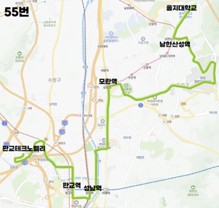

> 현재 출퇴근 배차간격(12분)을 절반 이하로 단축할 필요가 있으며, 혼잡도와 경로 우회율을 줄이기 위해 노선을 두 개로 분리하여 주요 거점을 분산 운행하는 방식으로 개편하는 것이 바람직

[figure not shown]

> 351번 노선은 정자역과 이매역을 분리하여 각각 전담하는 두 개의 노선으로 분할 운행하고, 배차간격을 10분 이내로 줄이는 방식의 개편이 필요

[figure not shown]

**🚌87번 (클러스터 1)**  
**ㆍ노선 특징**  
- 87번은 성남시 중원구의 8호선 접근성이 떨어지는 지역을 출발해 모란역을 거쳐 판교 제2밸리로 향하는 노선(퍼스트마일 문제가 있는 지역을 커버한다는 점에서 우수)  
**ㆍ노선 문제**  
- 8시 혼잡도 7.57, 18시 혼잡도 6.4로 매우 높게 나타나 과밀로 인한 승차 불편 및 지연 가능성이 존재  
- 87번은 승용차 통근량이 높은 클러스터1 지역에서 모란역의 중요한 라스트마일 연계 수단이기 때문에 이러한 혼잡도는 대중교통 이용을 저해시킬 수 있음  
**🛠️ 개선 방안**

> 현재 출퇴근 배차간격은 10분이지만, 혼잡도 감소를 위해 7~8분 간격으로 단축 운행이 필요하며 노선 경로 자체는 효율적이므로 분리보다는 배차만 조정하는 방식이 적절

[figure not shown]

> 현재는 출근 시간대에만 한정 운행 중이므로, 퇴근 시간대(17시~20시)에도 동일한 패턴으로 운행을 확대하는 것이 효과적일 것으로 판단됨

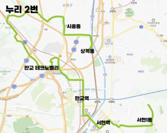

**🚌누리2번 (클러스터 3)**  
**ㆍ노선 특징**  
- 누리2번은 서현동 일대를 커버하며 판교역과 제2밸리를 연결  
**ㆍ노선 문제**  
- 다만 현재 노선이 이매역을 경유하지 않고 남쪽 지역을 우회하기 때문에, 이매역의 라스트마일 기능을 충분히 수행하지 못하고 있음  
**🛠️ 개선 방안**

> 출퇴근 배차간격이 16분으로 다소 긴 편이므로, 이매역을 경유하도록 노선을 일부 수정하고, 배차간격을 줄이는 방안을 제안(해당 개선을 통해 현재 이매역에서 제2밸리로 연결되는 버스 노선이 부족한 문제를 보완 가능)

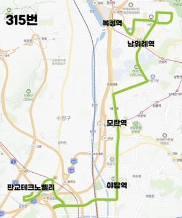

315번 노선도

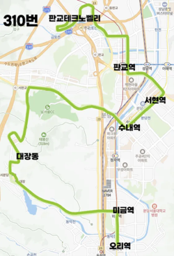

310번 노선도

> 혼잡도는 다소 높지만, 배차 간격(12분)을 조정하는 수준에서 충분히 대응 가능하며 노선 개편은 불필요